# Comparative Analysis of the Homeless Veteran and Non-Veteran Demographic Profiles and Disabilities at Urban Ministries of Durham

Meagan Foster

December 1, 2019

## Objectives

.Homeless veterans in the US

.Compare race, gender, and age for non-veteran and veteran clients at UMD

.Compare prevalence of disabilities for non-veteran and veteran clients

.Summary

See ReadMe.md for more information on data sources and project structure.

## Overview

.Approximately 11% of the homeless population are veterans

.Most Veterans who experience homelessness are men over age 50 living in urban areas.

.Among Veterans experiencing sheltered homelessness in 2016, about 9 in 10 (91%) were men, about the same as for all U.S. Veterans.

.Veteran women are more than twice as likely as non-Veteran women to experience homelessness.

.Nearly 6 out of 10 (59.1%) Veterans experiencing sheltered homelessness in 2016 were age 51 or older

.Veterans experiencing sheltered homelessness were 3.3 times more likely to identify as African American or Black, compared to all U.S. Veterans (38.2% vs. 11.4%) in 2016

.A majority (55%) of Veterans experiencing sheltered homelessness had a disability

Among Veterans experiencing homelessness who received health care services from the VA:

.More than one in four (28%) received diagnoses of chronic medical conditions

.More than one in four (28%) received a diagnosis of depression

.One in eight (13%) received a diagnosis of PTSD

.About one in five (19%) received a diagnosis of alcohol abuse

.About one in five (20%) received a diagnosis of drug abuse.

## How does the demographic characteristics of a homeless veteran compare to that of a non-veteran at UMD?

Chart1. Veteran Status by Gender

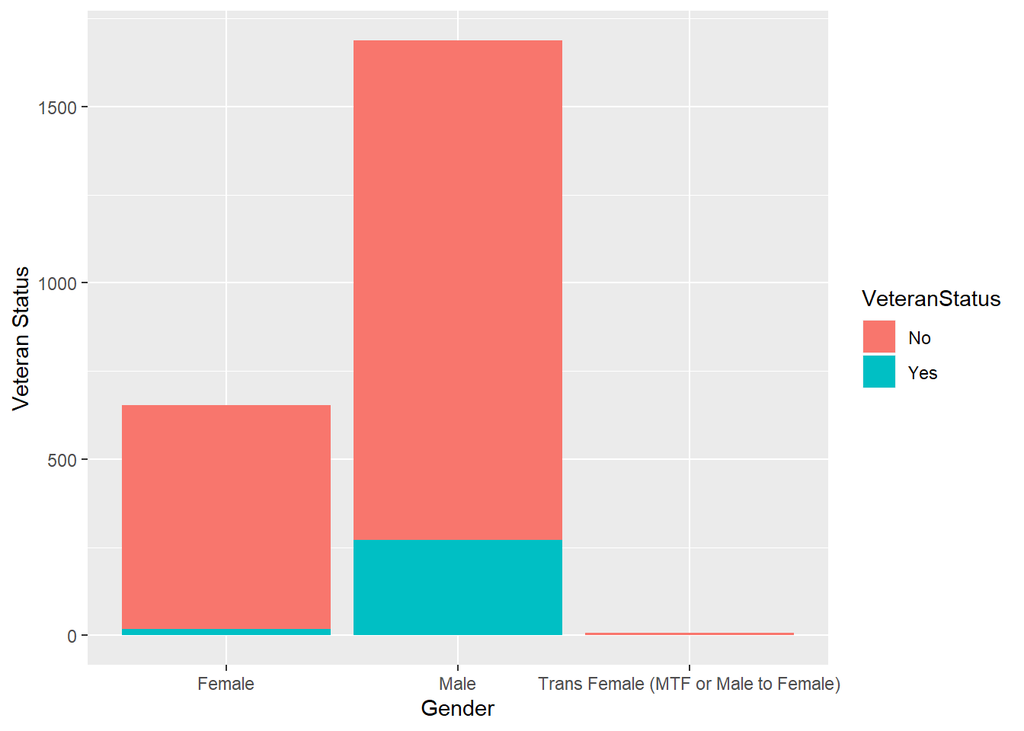

Additional info:

.16% of the male clients at UMD are veterans

.3% of the female clients at UMD are veterans

.1 of 8 Trans Female (MTF or Male to Female) UMD clients are veterans

Chart2. Veteran Status by Race

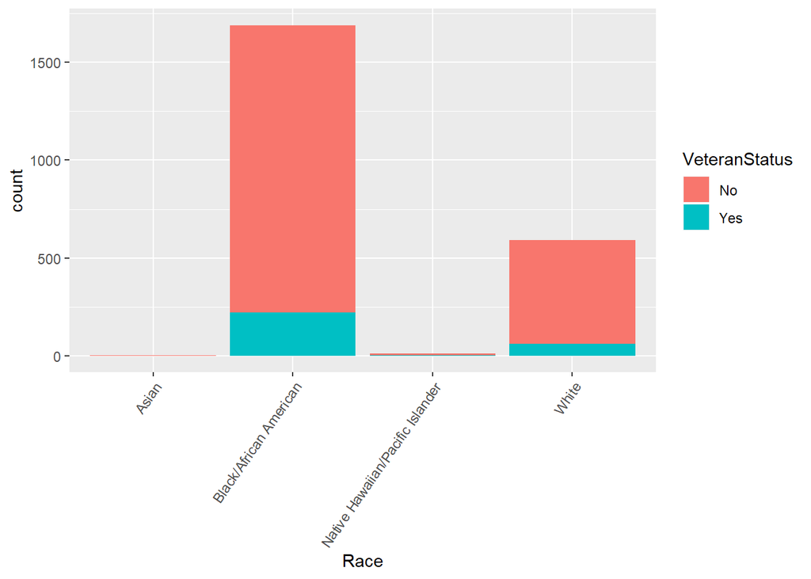

Chart3. Veteran Status by Age

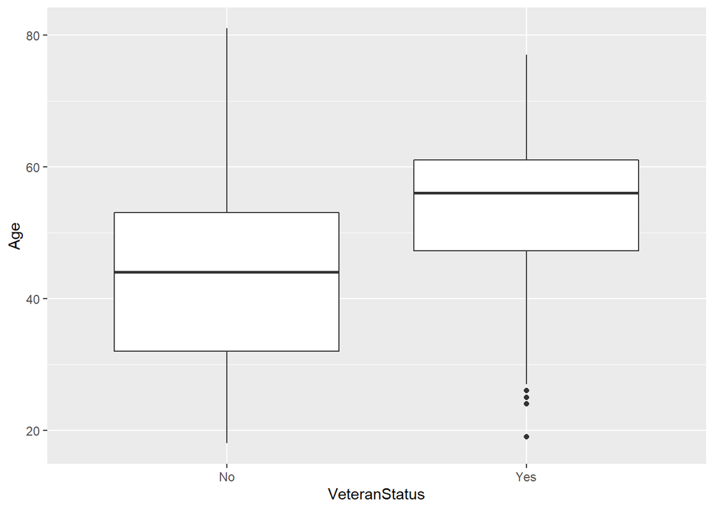

.The average age of a veteran client is 53 years old

.The average age for a non-veteran client is 43 years old

## How does the number of reported disabilities by a homeless veteran compare to that of a non-veteran at UMD?

.63% of the veterans at UMD have reported one or more disability

.53% of non-veterans at UMD have reported one or more disability

## Conclusion

.Veterans report disabilities at a higher rate than non-veterans